# Лабораторная работа №13

Настройка NFS

Жукова Арина Александровна

1132239120@rudn.ru

Российский университет дружбы народов

2025-11-29

# Информация

## Докладчик

- Жукова Арина Александровна
- Студентка 3 курса
- Российский университет дружбы народов им. П. Лумумбы
- 1132239120@rudn.ru

# Вводная часть

## Цель и задачи

**Цель:** Приобретение навыков настройки сервера NFS для удалённого доступа к ресурсам

**Задачи:**

- Установить и настроить сервер NFSv4
- Подмонтировать удалённый ресурс на клиенте
- Подключить каталоги веб-сервера и пользователей к дереву NFS
- Автоматизировать процесс развёртывания через Vagrant

# Выполнение работы

## Настройка сервера NFS

**Основные этапы:**

- Установка nfs-utils
- Создание корневого каталога
- Настройка экспорта
- Конфигурация безопасности

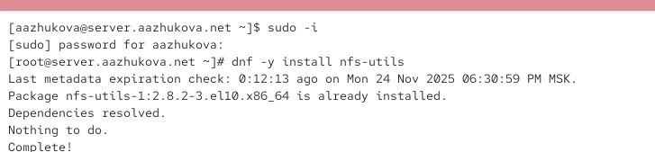

Установка nfs-utils на сервере

## Конфигурация экспорта и безопасности

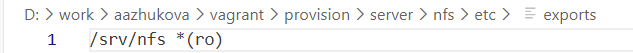

Настройка экспорта в /etc/exports

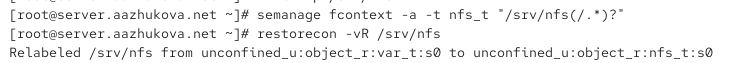

Настройка SELinux контекста

## Настройка сетевой безопасности

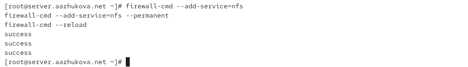

Настройка межсетевого экрана

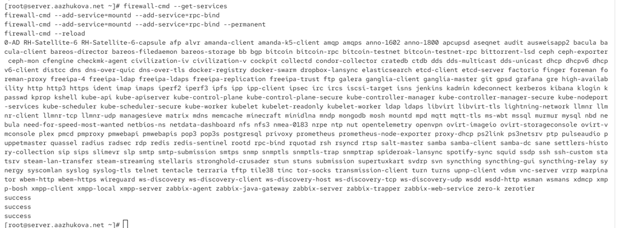

Добавление служб rpc-bind и mountd

## Настройка клиента

**Действия на клиенте:**

- Установка nfs-utils
- Проверка доступности ресурсов
- Монтирование NFS
- Настройка автоматического монтирования

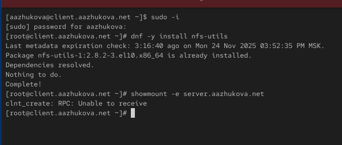

Установка nfs-utils на клиенте

## Монтирование и проверка

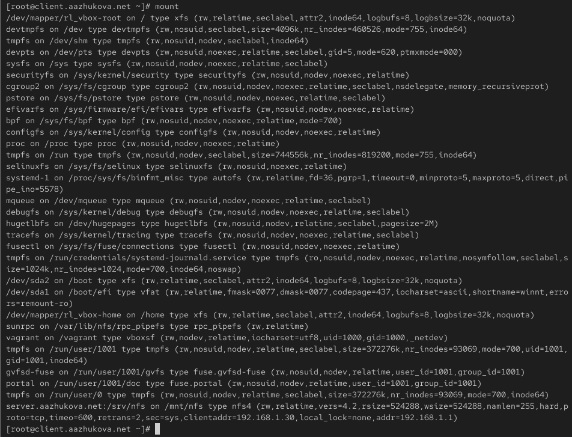

Проверка смонтированных ресурсов

## Автоматическое монтирование

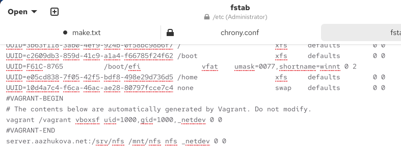

Добавление записи в fstab

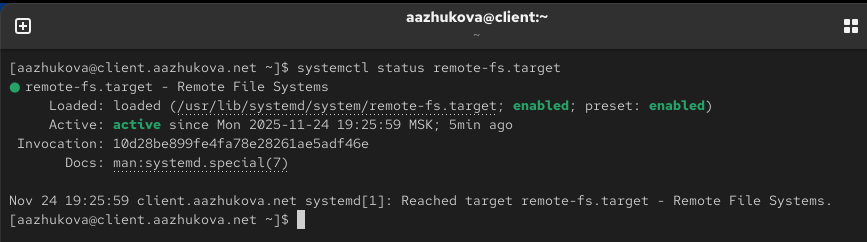

Проверка после перезагрузки

## Интеграция веб-сервера

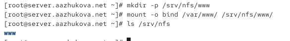

Bind-монтирование веб-каталога

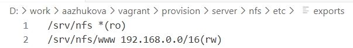

Экспорт веб-каталога

## Пользовательские каталоги

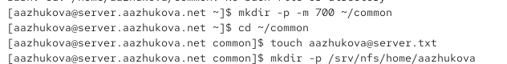

Создание пользовательского каталога

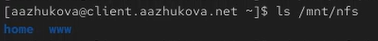

Проверка на клиенте

## Автоматизация с Vagrant

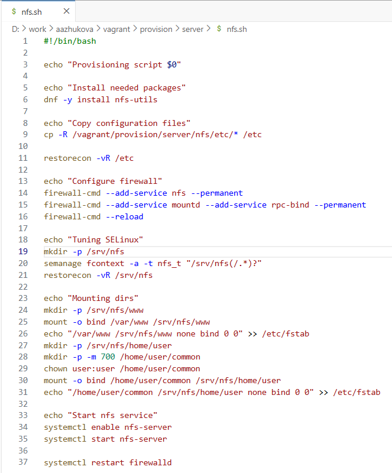

Скрипт настройки сервера

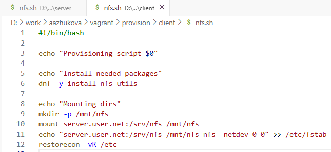

Скрипт настройки клиента

# Результаты

## Достигнутые результаты

**Успешно выполнено:**

- Настроен сервер NFSv4 с экспортом ресурсов
- Обеспечен удалённый доступ с клиентской машины
- Интегрированы каталоги веб-сервера и пользователей
- Решены проблемы сетевой безопасности
- Автоматизирован процесс развёртывания

## Ключевые показатели

- **Доступность**: Сервер NFS успешно экспортирует ресурсы
- **Безопасность**: Настроены правила firewall и SELinux
- **Автоматизация**: Реализовано автоматическое монтирование
- **Интеграция**: Веб-сервер и пользовательские каталоги подключены к NFS
- **Воспроизводимость**: Созданы скрипты для Vagrant

# Выводы

## Итоги работы

- Освоены практические навыки настройки NFSv4
- Изучены принципы работы сетевых файловых систем
- Приобретён опыт решения типичных проблем доступа
- Реализована интеграция NFS с существующими сервисами
- Создана автоматизированная система развёртывания

## Практическая значимость

**Полученные компетенции:**

- Настройка сервера NFS
- Управление сетевыми ресурсами
- Работа с сетевыми протоколами
- Автоматизация развёртывания
- Решение проблем безопасности

## Благодарности

**Благодарю за внимание!**

**Контакты:**

- 1132239120@rudn.ru